# Intro to Unsupervised Learning

#### Taylor Rohrich (trr2as), Siddharth Surapaneni (sss2ea), Prabhjot Singh (ps4fk), Ben Cosgro (bcc5d)

Hosted version of this document found [here](https://taylorrohrich.github.io/data_mining_final_project/)

## Introduction

Unlike supervised learning where we have a response variable that we are interested in measuring, unsupervised learning attempts to find interesting trends and potential sub groupings of observations within datasets that lack a response variable. This presents an interesting challenge to data science as we no longer have the ability to measure how accurate our modeling or analysis is by comparing prediction to the true response variable. Instead we must take a more subjective approach to understanding the data. Therefore the methods used in unsupervised learning are typically a form of exploratory analysis. There are a variety of ways in which unsupervised learning may be implemented, but we will limit our tutorial to two main types: Principal Component Analysis (PCA) and Clustering. In addition, we recommend this tutorial for students that have been exposed to using preliminary statistical methods in R.

## Principal Component Analysis

### Introduction:

Prior to jumping into PCA as a whole, let’s first examine what principal components are. When given a large dataset with many variables, it can be difficult to fully comprehend and visualize the patterns and trends in the data. Principal components can help us create a smaller representative set of variables to explain the same amount of variance seen in the large dataset with all variables. Furthermore, the process of computing these components and a smaller set of features, also known as reducing dimensionality, is called Principal Component Analysis (PCA). PCA can be a very useful data visualization and pre-processing tool for a variety of methodologies including both supervised and unsupervised learning. However for this tutorial we will limit its use to the unsupervise realm of data science.

In order to understand how PCA works, we must understand how to be able to calculate the first principal component. Let’s first take a look at a simple dataset. We will be using the `birth.death.rates.1966` dataset in the `cluster.datasets` R package. This is a dataset that contains the birth and death rates per 1000 persons for 70 different countries. Here is what we get by simply plotting the deaths rates for each country against the birth rates.

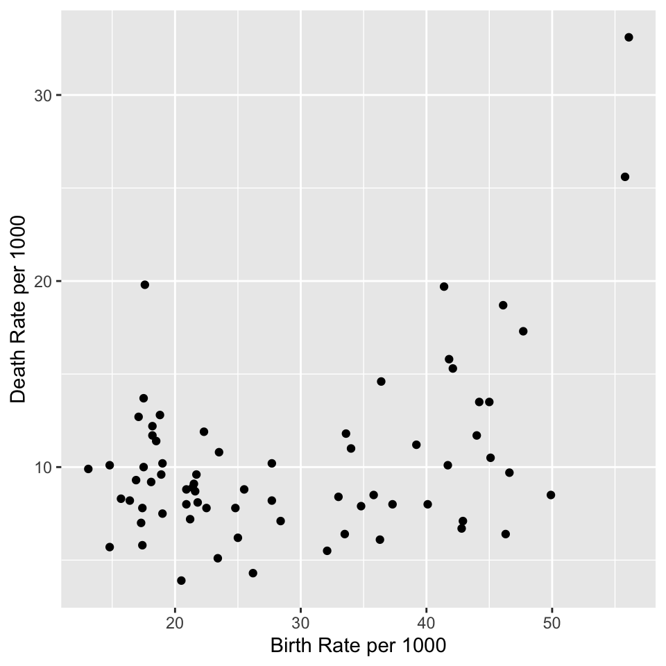

When computing the first principal component, we are really trying to find a way to best represent the whole feature space in one dimension. We are trying to find the direction in the feature space that has a high amount of variation between the two data points. As we notice from above, there is more variance in the birth rates between the countries than there is between the individual death rates between the countries. However, the most amount of variability of the data between the countries in one dimension could actually be better represented by a feature that can be expressed as a linear combination of the birth rates and death rates of a country and this is how PCA in simplified terms, is reducing the dimensionality of the data set.

### How PCA works:

1. In order to find the feature that accounts for most of the variability through PCA, we must first scale the data so that all of the k features have a mean of 0 and a variance of 1. As such this is a method that can only work with quantitative data.
2. Once we scale these points, we must find the sum of squared distances of the scaled data projected onto a random line through the origin to the origin itself. The goal is to ultimately find the line that maximizes this distance. This line is called our first principal component. The slope of the line can help us determine which feature is of most importance, as it can be seen as a sort of ratio between all our features in the data. We can obtain the loadings from this step too, as they are simply the ratios or weights associated with the features that make up the component. Another way to think of the principal component is as a normalized linear combination of the features in our data: *Equation From ISLR section 10.2.1 (p. 375)*

   $z_{1}=\phi_1x_{1}+\phi_2x_{2}+...+\phi_kx_{k}$

   Where the weights, $\phi$, of the component are the loadings. One of the constraints of PCA is that the sum of squares of the loadings must equal one. Again, we can use these loadings to see how much each of the k features contributes to the principal component. From here, we want to maximize the variance of this principal component with respect to the constraint of the loadings. *Equation from ISLR section 10.2.1 (p. 376)*

   **Maximize** {$\frac{1}{n}\sum_{i=1}^{n}(\sum_{j=1}^{k}\phi_j^{2}x_{ij})^2$} **subject to $\sum_{j=1}^{k}\phi_j^{2} = 1$**

   This gets our first component. *From ISLR section 10.2.1 (p. 376)*

   $z_{i1}=\phi_1x_{i1}+\phi_2x_{i2}+...+\phi_kx_{ik}$
3. From this principal component, we can get a value for the feature for each of the data points which in this case is known as the principal component score.
4. We again repeat this process with the second component, with the additional constraint of making sure that the individual components are uncorrelated with each other, which in linear algebra translates to each principal component being orthogonal to one another. We continue computing the principal components depending on how many dimensions we have in our data. For data with k-dimension we generally get k-principal components or if the sample size, n, is less than the number of features, we get n-1 principal components.
5. From here we can use the sum of square distances calculated for each principal component in step 2 to determine which of our principal components account for the most variance seen in the data. The principal components that are deemed the most important can then be used as a method to either graph or explain the data in a reduced state. This not only will allow us to visualize the data in two dimensions, but also can be helpful in the reduction of noise seen in high dimensional data and thus be used in combination with other unsupervised methods such as clustering. This will be explained in more detail later on.

Through this process, we are able to get prinicipal components that we can assess in order to help us reduce the dimensionality of the data to a smaller subspace of features, that are linear combinations of the variables in the data, and these new features can explain most of the variability in our data.

### Working with A High Dimension Dataset

Now that we have a better understanding of how PCA works, let us apply it on a dataset that has more than 2 dimensions. In R, we can use the `prcomp` function from the `stats` package to do Principal Component Analysis and make all the needed computations discussed above. We will be using the US Education dataset from kaggle that contains data for all 50 states as well as the District of Columbia for years from 1992 to 2019, and has features such as Enrollment, total_revenue, instruction expenditure, the state’s average math score for the NAEP exam,etc. For this tutorial we will mainly focus on the year 2013.

[Dataset Link](https://www.kaggle.com/noriuk/us-education-datasets-unification-project?select=output_data)

We will filter the data to only include the year 2013 and remove rows with any na values. Performing this clearing still leaves us with data on all 50 states as well as the District of Columbia. A sample of some of the predictors in the dataset is shown below.

```r
#Only using data from 2013
states_education=states_education%>%filter(YEAR==2013)
#Removing any rows with NA Values
states_education=na.omit(states_education)
knitr::kable(head(states_education[,c('STATE','YEAR','ENROLL','TOTAL_REVENUE','INSTRUCTION_EXPENDITURE')]), format="markdown")
```

| STATE | YEAR | ENROLL | TOTAL_REVENUE | INSTRUCTION_EXPENDITURE |
| --- | --- | --- | --- | --- |
| ALABAMA | 2013 | 744548 | 7197439 | 3747993 |
| ALASKA | 2013 | 131091 | 2545117 | 1324649 |
| ARIZONA | 2013 | 941726 | 8164324 | 3824071 |
| ARKANSAS | 2013 | 477716 | 5067546 | 2545564 |
| CALIFORNIA | 2013 | 6208733 | 68868516 | 34194878 |
| COLORADO | 2013 | 851063 | 8826868 | 4292898 |

Then we may turn this data into an unsupervised learning problem by removing the state names altogether, and furthermore perform PCA.

```r
educationPCA=prcomp(states_education%>%select(-c(STATE,`PRIMARY_KEY`,YEAR)),scale=TRUE)
#Getting the standard deviations for each of the principal components
educationPCA$sdev
```

```
#>  [1] 4.094301e+00 1.906036e+00 8.134293e-01 6.322587e-01 4.750596e-01
#>  [6] 3.817859e-01 2.592731e-01 1.932851e-01 1.515561e-01 1.338168e-01
#> [11] 1.119774e-01 8.007656e-02 6.169539e-02 3.821707e-02 2.295696e-02
#> [16] 1.725984e-02 1.315956e-02 1.114625e-02 6.138831e-03 5.180802e-03
#> [21] 2.159336e-03 1.132583e-16
```

```r
#Displaying the data for the first five Prinicipal Components
#rotation contains this matrix of variable loadings
knitr::kable(educationPCA$rotation[,c('PC1','PC2','PC3','PC4','PC5')],format="markdown")
```

|  | PC1 | PC2 | PC3 | PC4 | PC5 |
| --- | --- | --- | --- | --- | --- |
| ENROLL | 0.2419621 | -0.0140212 | -0.1291295 | 0.1163233 | 0.0417397 |
| TOTAL_REVENUE | 0.2373001 | 0.0399796 | 0.2518779 | -0.1359334 | -0.0452634 |
| FEDERAL_REVENUE | 0.2403864 | -0.0528043 | -0.0870846 | 0.1443101 | -0.0126500 |
| STATE_REVENUE | 0.2360724 | 0.0199076 | 0.2267997 | 0.1104515 | -0.1289760 |
| LOCAL_REVENUE | 0.2233426 | 0.0729903 | 0.3240984 | -0.3961925 | 0.0239334 |
| TOTAL_EXPENDITURE | 0.2375347 | 0.0383853 | 0.2477471 | -0.1351961 | -0.0432972 |
| INSTRUCTION_EXPENDITURE | 0.2282626 | 0.0498912 | 0.3732340 | -0.2117581 | -0.0164610 |
| SUPPORT_SERVICES_EXPENDITURE | 0.2389186 | 0.0356857 | 0.1997263 | -0.0774200 | -0.0376635 |
| OTHER_EXPENDITURE | 0.2394001 | -0.0004058 | -0.0630681 | 0.1524461 | 0.0672820 |
| CAPITAL_OUTLAY_EXPENDITURE | 0.2371749 | -0.0054931 | -0.0194485 | -0.1047214 | -0.1145518 |
| GRADES_PK_G | 0.1839862 | -0.0041086 | -0.5897103 | -0.6928566 | 0.1772363 |
| GRADES_KG_G | 0.2407701 | -0.0248109 | -0.1457078 | 0.1618363 | 0.0245890 |
| GRADES_4_G | 0.2417292 | -0.0160693 | -0.1418119 | 0.1113770 | 0.0238529 |
| GRADES_8_G | 0.2418780 | -0.0148191 | -0.1270313 | 0.1201615 | 0.0300676 |
| GRADES_12_G | 0.2401525 | -0.0100782 | -0.0525529 | 0.2559988 | -0.0360515 |
| GRADES_1_8_G | 0.2416362 | -0.0159901 | -0.1433365 | 0.1115739 | 0.0316052 |
| GRADES_9_12_G | 0.2420137 | -0.0114087 | -0.0872947 | 0.1680728 | 0.0084013 |
| GRADES_ALL_G | 0.2420280 | -0.0144136 | -0.1348579 | 0.1027274 | 0.0273345 |
| AVG_MATH_4_SCORE | -0.0240740 | 0.4968074 | -0.1728672 | 0.0881360 | -0.2362859 |
| AVG_MATH_8_SCORE | -0.0020701 | 0.4965270 | -0.1346203 | -0.0829748 | -0.5837743 |
| AVG_READING_4_SCORE | -0.0044548 | 0.4879259 | 0.0882920 | 0.0821985 | 0.7109789 |
| AVG_READING_8_SCORE | -0.0002814 | 0.5011913 | 0.0272210 | 0.0582934 | 0.1375027 |

Running the `prcomp` function we can obtain the standard deviations of the principal components and a matrix of variable loadings. Since we have 22 features, we know that we will also have 22 principal components. The output above shows the first 5 of the 22 principal components. However, generally we only need to consider the first few components as they typically explain most of the variance seen in the data. Looking at the first principal component, we can deduce the most important features by looking at which features have the greatest loadings. In this case, we observe that variables related to revenue, expenditure and number of students in specific grades to be the most important. Given that we scaled the data, states with above average total revenues, above average amount of expenditure, as well as an above average number of students in each of the grade levels would have a higher score for this principal component. As we see the first component seems to be a feature that is indicative of how large the state is as loadings are fairly distributed across features like expenditure, revenue, number of students in the different grade levels. There is less emphasis on the test scores in this component. So states with larger populations like California would probably have higher scores for this principal component.The second component is a feature that seems to be more indicative of a state’s academic performance as the loadings of this component put emphasis on features related to the test scores in math and reading.

To see how many Principal Components are needed to best represent the data, we can use a scree plot to assess how many principal components are needed to capture the variance in the data. This plot gives us the variances of each principal component. As we can see from the scree plot below, the first two components seem to be explaining most of the variance that is found in the data.

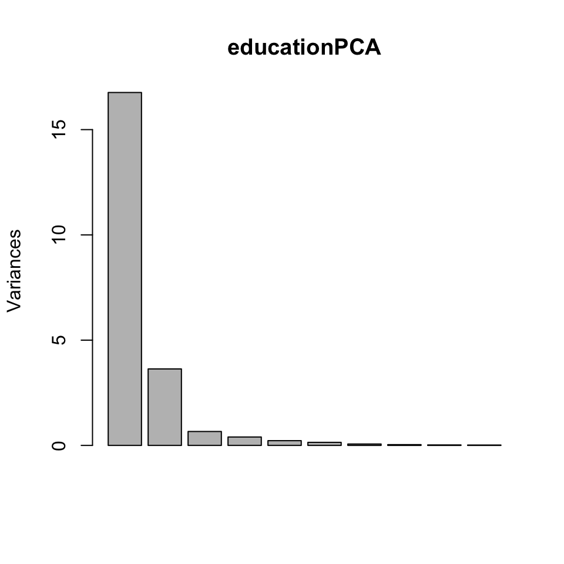

```r
#plotting the screeplot
screeplot(educationPCA)
```

As we can see through this scree plot, we can reduce this 22-dimension data to 2-dimensions while still taking into account the 22 features of the dataset. With 2 dimensions we can now adequately visualize this rather complex dataset.

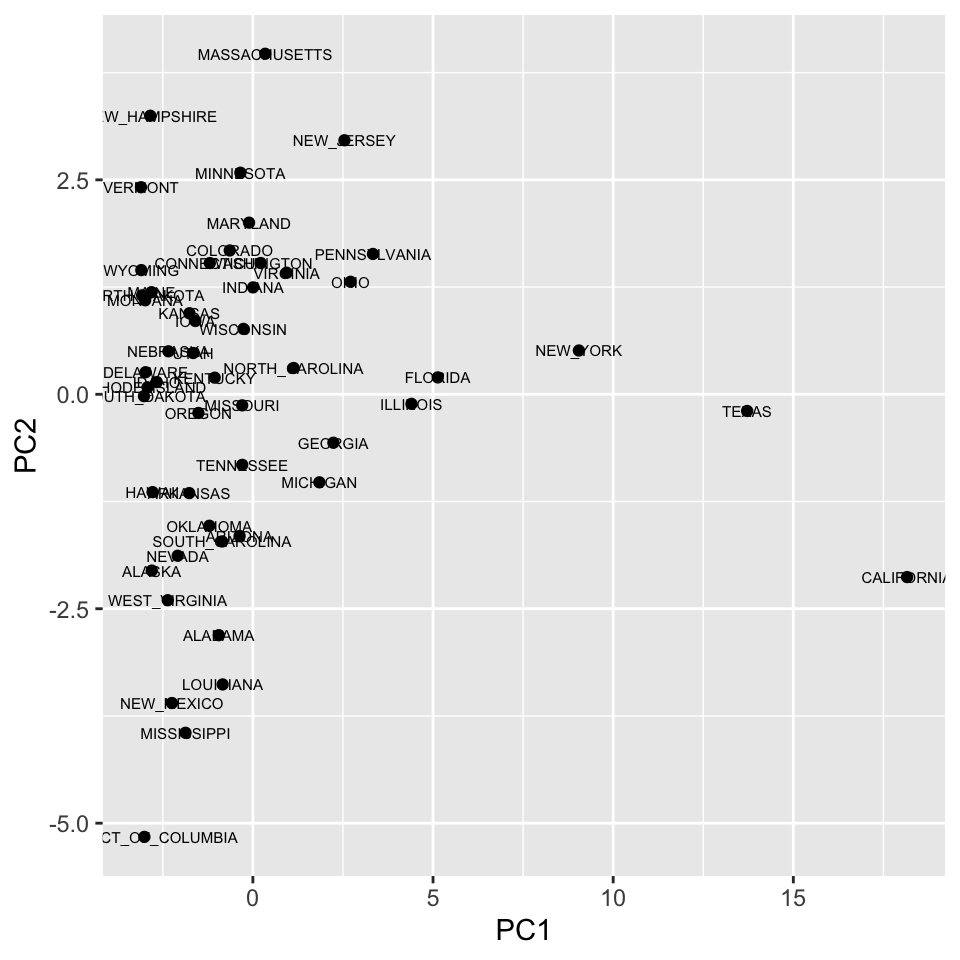

```r
#Plotting the first two components with first principal component on the x-axis and the second on the y-axis
state_tibble=tibble(state=states_education$STATE,PC1=educationPCA$x[,"PC1"],PC2=educationPCA$x[,"PC2"])
ggplot(data=state_tibble,aes(x=PC1,y=PC2))+geom_point()+geom_text(label=state_tibble$state,size=2)
```

Through this visual representation and our understanding of the first two principal components, we can see that through the first component, California is one of the largest states in the country based on its spending, revenue and number of students in the different grade level but we also see through the second component the academic performance of students is weaker when compared to most of the other states in the country.

## Clustering

### Overview

Clustering is a unsupervised learning technique that seeks to group similar objects together. It is often used during exploratory data analysis to investigate potential patterns in data points. Although all types of clustering seek to group similar objects, the notion of how ‘similarity’ is defined distinguish one type of clustering algorithm from another. Three major types of clustering algorithms are$^2$:

- **Connectivity-Based Clustering**
  - Objects are similar to closer objects rather than to far away objects.
- **Centroid-Based Clustering**
  - Objects are similar if they are close to the same centroid.
- **Distribution-Based Clustering**
  - Objects are similar if they come from the same distribution.

### Sample Dataset

To analyze clustering we will again look at the `birth.death.rates.1966` dataset in the `cluster.datasets` R package. This package contains the birth and death rates per 1000 people for 70 countries. We again can visualize this data below:

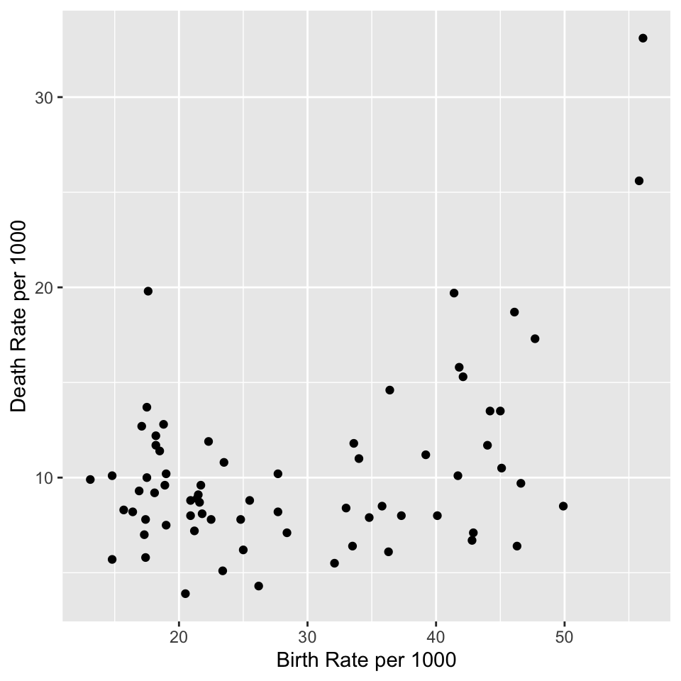

### Distance

Regardless of the specific algorithm used, clustering often requires a notion of *distance* between objects. Because distance is used in these algorithms, it is often important to *scale* your data so that a particularly high-magnitude feature does not exert excessive influence in the clustering. There are several different types of distance metrics, and the right one to use depends on the problem at hand$^1$.

#### Euclidean Distance

$d(x,y) = \sqrt{\sum_{i=1}^n(x_i-y_i)^2}$

Euclidean Distance is often the default type of distance chosen for the problem, it simply represents the distance between two points in euclidean space.

#### Manhattan Distance

$d(x,y) = \sum_{i=1}^n\lvert(x_i-y_i)\rvert$

Manhattan Distance can be thought of as the shortest path between two points in euclidean space, with the restraint that the path can only move at right angles (similiar to a taxi car traversing a city). Manhattan Distance could be useful where the data naturally expresses distance in this format. For example, a chessboard can only be traversed in this form. The green line in the image below represents euclidean distance, and the red, blue, and yellow lines represent the shortest paths using Manhattan Distance. Image from [wikipedia](https://en.wikipedia.org/wiki/Taxicab_geometry).

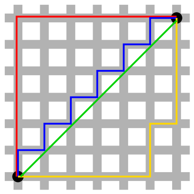

#### Pearson Correlation Distance

$d(x,y) = 1 - \frac{\sum_{i=1}^n (x_i-\bar{x})(y_i-\bar{y})}{\sqrt{\sum_{i=1}^n (x_i-\bar{x})^2 \sum_{i=1}^n (y_i-\bar{y})^2}}$

Instead of a distance metric grounded in euclidean space, the Pearson Correlation Distance is a correlation-based distance: it is essentially one minus the correlation between two objects. This is useful when we want to group items together when their components follow the same pattern (i.e, when one dimension in one component is high the corresponding dimension in the other component is high, and the same for low values), but the two items may not be close in euclidean space. An example of utilizing this type of distance metric is in DNA / gene expression analysis, where we are interesting in genes that follow the same ‘pattern’ together$^1$.

### Centroid-Based Clustering

In Centroid-Based Clustering, each cluster is defined by a centroid: the arithmetic mean of all points in the cluster. One of the most common Centroid-Based Clustering algorithms is **K-Means Clustering**.

#### Algorithm

The K-Means algorithm works as follows:

1. Initialize K means (centroids)
2. Assign each point to the closest mean, defined by the distance metric used.
3. Recompute the means by calculating the centroid of the updated points in that cluster.
4. Repeat steps 2. and 3. until no point assignment changes.

#### Initialization Methods

Although the iterative algorithm is fairly simple, the question remains on how to initialize the K means. There are two commonly used methods: the Forgy Method and the Random Partition.

##### Forgy Method

Randomly picks K points from the dataset to utilize as the initial K means. This often leads to initial K means that are fairly spread out$^3$.

##### Random Partition

Randomly assign each point to one of the K clusters. The centroids of these clusters are then computed and used as the initial K means. This often leads to initial K means that are close to the center of the data$^3$.

#### Number of Starts

One of the drawbacks of K-Means is that it is a *heuristic*, which means that the algorithm does not guarantee the globally optimum solution, but this allows for a computationally more efficient result. Because of this, K-Means can potentially find local optimum results that are often dependent on the initialization points. To help combat this, run K-means several times (using a random intialization method) and choose the best result (i.e, the one with the smallest within-cluster sum of squares).

#### Choice of K

As clustering is an unsupervised learning method, we do not have access to how many clusters in reality there are. However, we can estimate the number of clusters (the choice of K) several ways. One way is to inspect the data visually. For example in the scatter plot above there appears to be two main clusters of data; one could separate the data based on if the point has a birth rate greater or less than 30. Another, more analytic, option is to run K Means for a variety of K values and create a graph of the within-cluster sum of squares vs. K. In this graph one looks for the point of diminishing returns, i.e the point where increasing the number of clusters does not significantly decrease the within-cluster sum of squares. This is often referred to as the ‘elbow’ in the plot. The graph below shows how the clustering results change as we increase K for the `birth.death.rates.1966` dataset. After K = 2 or 3, the clusters appear to visually make less sense.

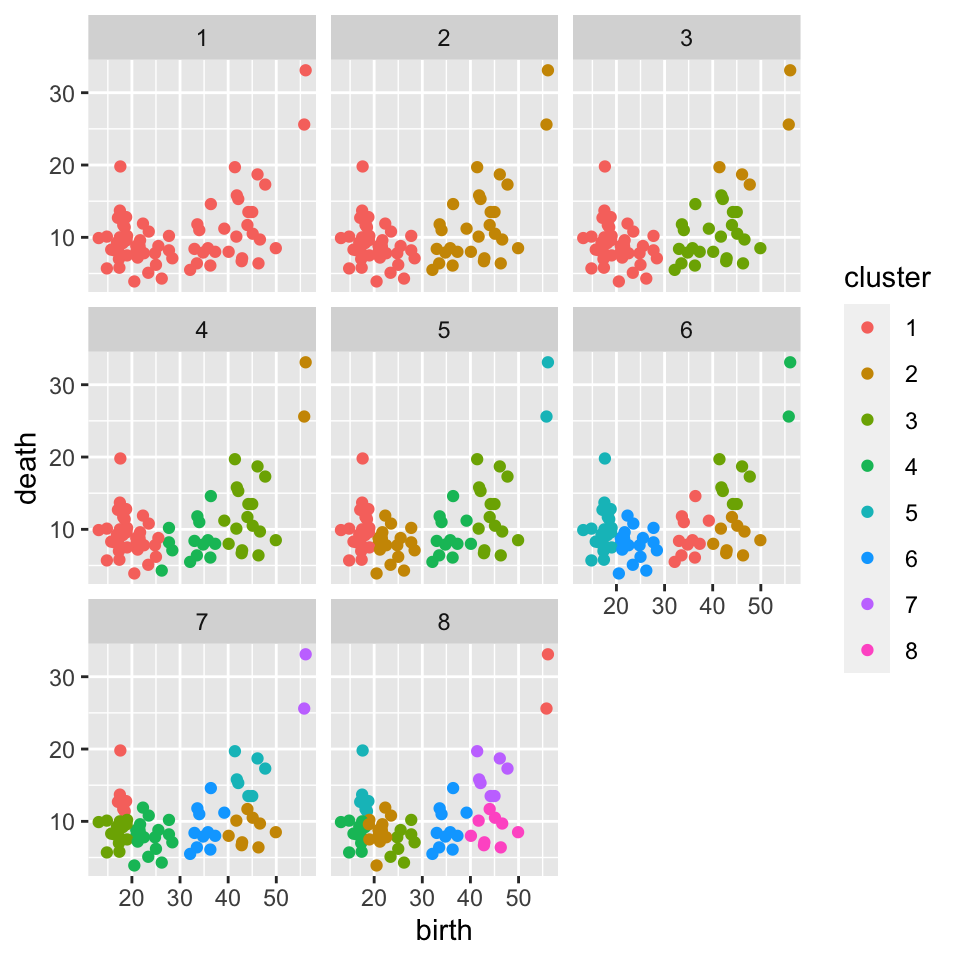

Additionally, we can look at the plot of SSE vs. K for the clusters above and find the same thing analytically: the ‘elbow’ in the plot appears at K = 2 or 3, suggesting this may be a good amount of clusters to go with.

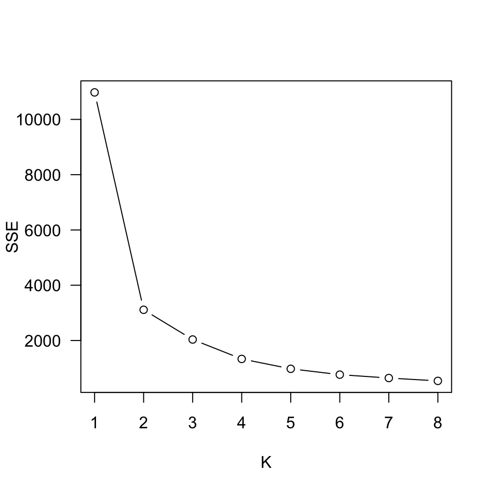

#### Example in R

Using the `kmeans` function in R, we can easily run K-Means on our sample dataset:

```r
km = kmeans(birth_death_rates, centers=2, nstart=25)
```

The `kmeans` function takes in the data, the number of centers (K), and the number of starts: this is the number of times that K-Means is run, choosing the ‘best’ run based on the smallest within-cluster sum of squares. The resulting variable contains a vector of the cluster assignment to each point; we can plot these visually below:

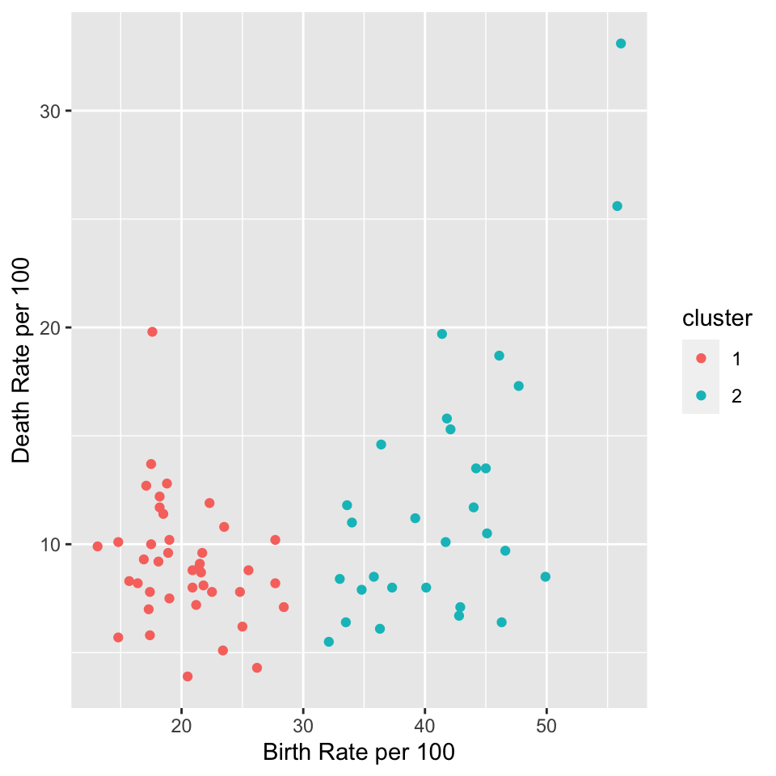

#### Advantages and Disadvantages to K-Means

There are several advantages and disadvantages to utilizing the K-Means algorithm as opposed to other clustering techniques.

##### Advantages

- Simple
  - K-Means is simple to implement, additionally libraries already exist that implement K-Means in both R and python.
- Guarantee of Convergence$^4$.
  - Although no guarantee that K-Means converged to a globally optimal solution.
- Scalability
  - Due to the heuristic nature of the algorithm, scales well to large data.

##### Disadvantages

- Choosing K
  - although there are several way to choose K, it is simply our ‘best guess’ of what reality is.
- Suffers with High Dimensionality
  - As is common with distance-based algorithms, as the number of features increases, the euclidean distance between points increases and the data are sparse within this volume, resulting in reduced effectiveness of K-Means.
- Outliers
  - Outliers will tend to pull the centroids of clusters, affecting the resulting clustering.
- Heuristic
  - K-Means is a heuristic, which means that we could potentially get stuck in a local optima.
- Hard Classification
  - K-Means gives us a binary answer in regards to which cluster a point belongs to. Other models, like Gaussian Mixture Models give us a probability of a point belonging to a class, which could help us quantify our uncertainty in the cluster assignment.

#### Distribution-Based Clustering

One of the disadvantages discussed above in K-Means is that points are assigned a hard classification to a single point. However, we can utilize distribution-based clustering to receive a soft-classification, or a probability, of a point belonging to a cluster. One of the main Distribution-Based Clustering algorithms is Gaussian Mixture Models. Gaussian Mixture Models treat the probability density distribution as being constructed of K different distributions$^5$:

$f(x) = \sum_{k=1}^K \pi_k * f_k(x)$

Where $\pi_k$ represents the probability of a point coming from distribution k and $f_k(x)$ represents distribution k. Specifically in Gaussian Mixture Models, each $f_k(x)$ is a gaussian with parameters $\mu_k, \sigma^2_k$. Gaussian Mixture Models attempt to estimate two things:

1. The parameter values
   - This includes the values of each $\pi$, as well as the parameters of the gaussians: $\mu_k, \sigma^2_k$.
2. The *responsibilities* of each data point: $p(z_j=1|x_i)$
   - This represents the posterior probability that each data point $i$ came from each distribution $j$.

These values are estimated using the iterative EM algorithm. This algorithm consists of the following steps:

1. Initialize the parameters. This can be done randomly or with an intuitive guess.
2. E Step:
   - Holding the parameter values fixed, estimate the new values of the responsibilities.
3. M Step:
   - Holding the updated responsibilities fixed, estimate the new vaues for the parameters.
4. Repeat steps 2 and 3 until approximate convergence (this could be when the values in the parameters change less than a specified threshold).

In practice, the EM algorithm can converge fairly quickly. Consider the output below running the EM algorithm on the `birth.death.rates.1966` data; after only 25 iterations it appears that the algorithm has captured the two clusters:

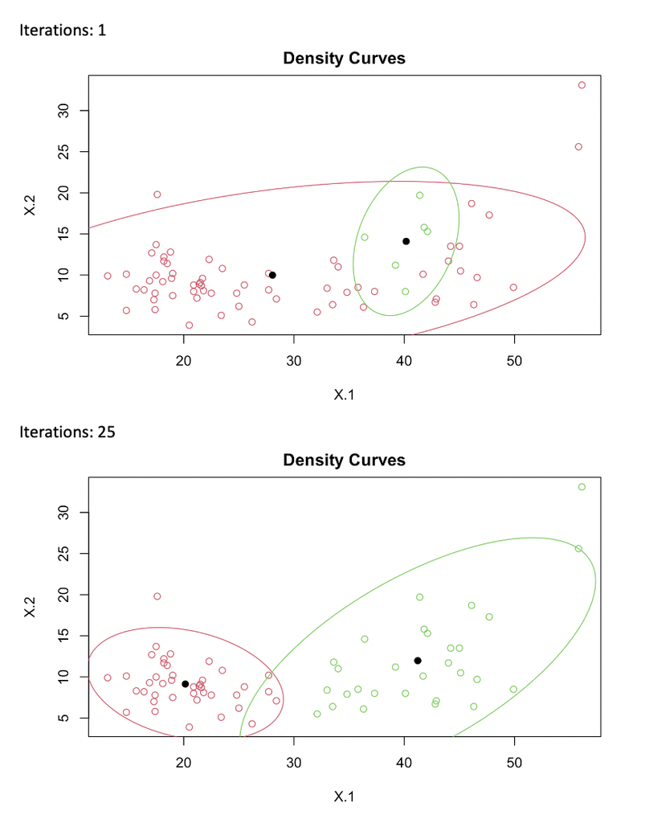

#### Soft Classification

As mentioned above the responsibilities calculated during the EM algorithm are *probabilities*: this provides more information than the hard classification provided by K-Means because it provides a measure of uncertainty in our results. This is especially important at the boundary points between the two distributions, allowing us to see how confident we can be in our results.

#### Example in R

Using the `mvnormalmixEM` function in the `mixtools` library, we can easily run the EM algorithm in R:

```r
GMM = mixtools::mvnormalmixEM(birth_death_rates, k=2)
```

```
#> number of iterations= 27
```

The function takes as parameters the data as well as the number of components k. We can easily plot the resulting component distributions as well.

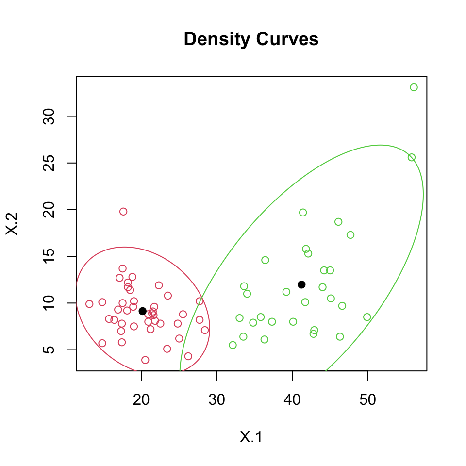

```r
plot(GMM, whichplots = 2, alpha=.05)
```

#### Advantages and Disadvantages to Gaussian Mixture Models

There are several advantages and disadvantages to utilizing Gaussian Mixture Models as opposed to other clustering techniques.

##### Advantages

- Soft Classification
  - Allows us to look at the probability of a point belonging to a class, as opposed to a hard classification
- Statistical View of Clustering$^5$.
  - Allows us to view the clustering problem as attempting to find the underlying distributions that generate the data
- Easily Interpretable.
  - Mixture Models are easy to understand as the weighted sum of different density distributions, and these distributions can be more easily visualized than K-Means.

##### Disadvantages

- Choosing K
  - Similar to K-Means, we have to choose K; it is simply our ‘best guess’ of what reality is.
- Stuck in Local Optima
  - Like K-Means, Gaussian Mixture Models can potentially get stuck in a local optima depending on the starting point.
- Scaling issues
  - As the number of dimensions or the number of distrubtions increases, EM can become computationally expensive.

### Connectivity-Based Clustering (Hierarchical Clustering)

Hierarchical Clustering similarly categorizes data based on distance from other points. However, where K-means has a set number of clusters, hierarchical clustering changes number of clusters depending on a threshold between 0 and some maximal value. If we had a cluster where the highest maxmial value was 1 and we chose a threshold of 0, all observations would be their own cluster. A threshold of 1 assigns all observations to 1 cluster.

In order to utilize this threshold, we first must calculate the distance between observations. Different ways of determining these distances are called linkages. We will address that further down. As seen in K-means, we can visualize data in a scatter plot. By finding the distance between observations, we can get a good idea of where closer connections will be on a dendrogram and where clusters might make sense. In this example, 1 and 6 as well as 5 and 7 will likely be our closest pairs and therefore be our starting points$^7$.

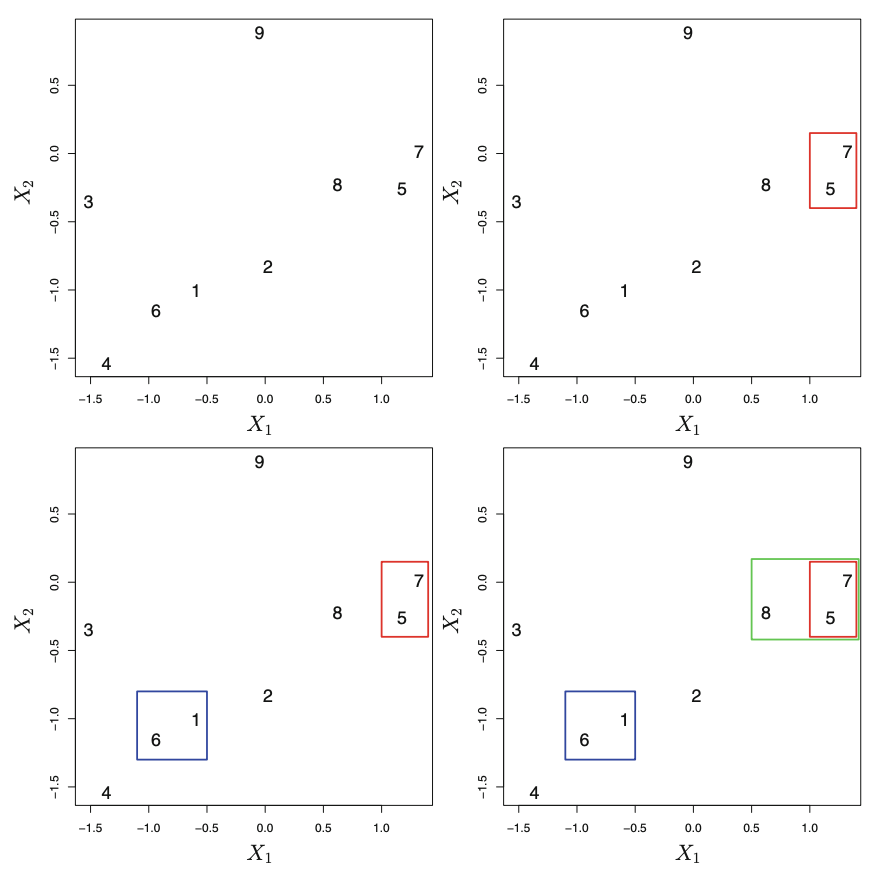

Cluster Points

An example of a possible dendrogram for this example is seen below$^7$.

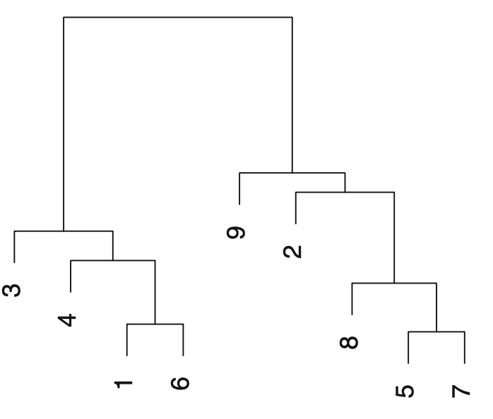

#### Types of Clustering

We can now cluster our observations from the `birth.death.rates.1966` using different types of linkage. While the two main linkages are Average and Complete linkage, one can also use Single and Centroid linkage. In single linkage we find the shortest distance between two points and cluster them. From that point we find the next shortest distance. If points 1 and 2 are clustered together and 4 and 5 are clustered together on opposite sides of 3, 3 will go into the cluster containing the closest of the 4 independent points.

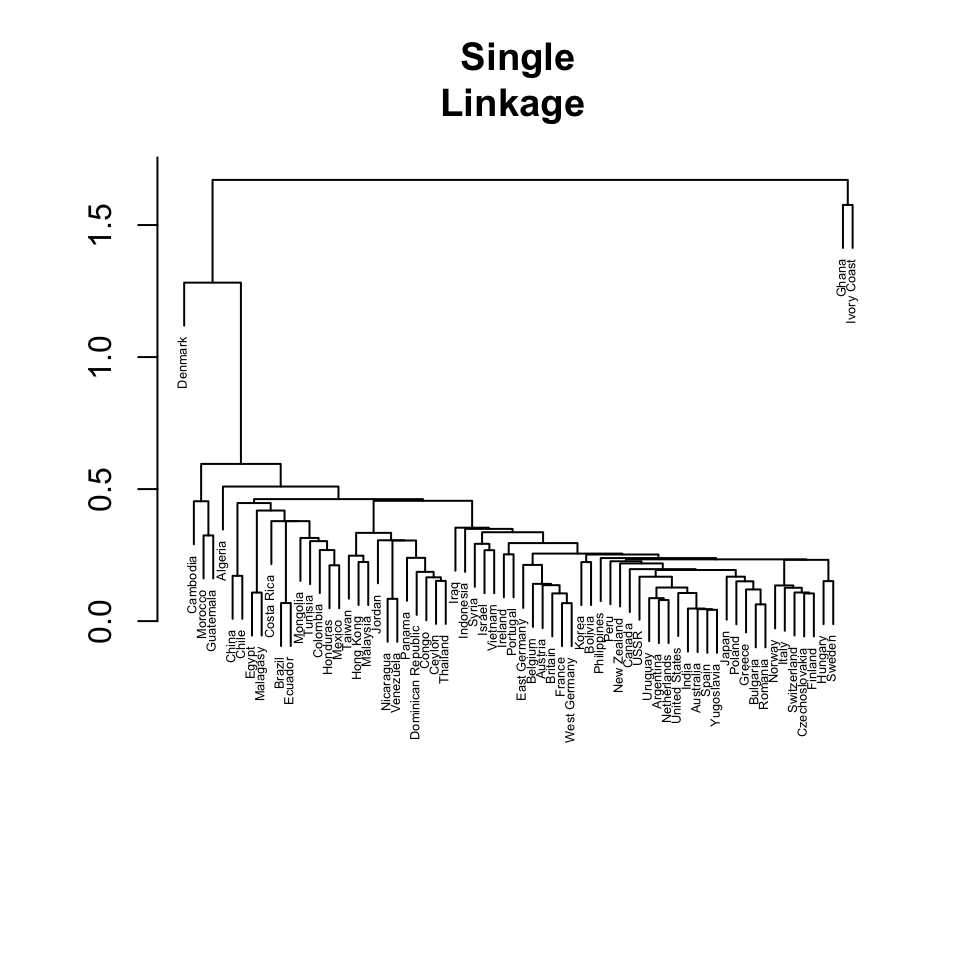

```r
data.labs = data$country
sd.h.data=scale(birth_death_rates)
h.data.dist=dist(sd.h.data)
plot(hclust(h.data.dist, method = 'single'), labels=data.labs , main="Single
Linkage ", xlab="", sub="",ylab="", cex = .4)
```

In complete linkage, the opposite happens. In our example with the cluster containing 1 and 2 and a cluster containing 4 and 5, 3 will go to the cluster that does not contain the independent point farthest from it. Complete linkage can be superior to single linkage where single linkage might be creating a large cluster that spans a large area and truly should have been more than one cluster but instead continually ends up being closer to each point. With complete linkage, by basing distance on the farthest point, we push the center of the cluster away and discourage unification of too many clusters.

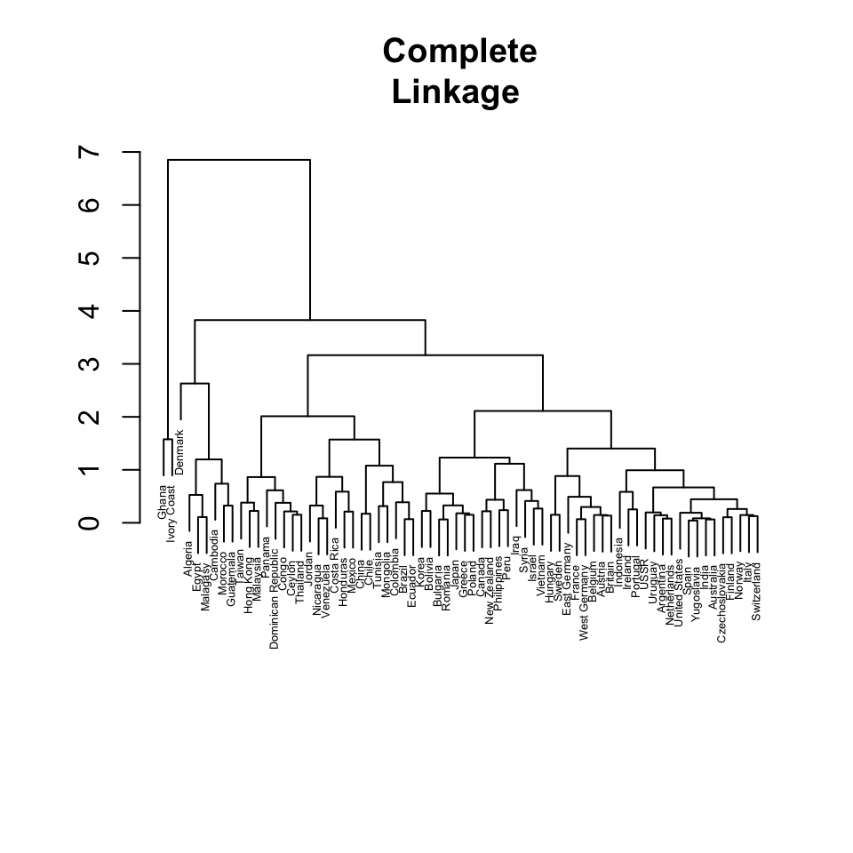

```r
plot(hclust(h.data.dist), labels=data.labs , main="Complete
Linkage ", xlab="", sub="",ylab="", cex = .4)
```

In average linkage, we unsurprisingly take many averages. In our example above, in order to find distance, we would take the average of the distance from 3 to 2 and 3 to 1 to find the distance between the 3 cluster and the cluster containing 1 and 2. Similarly we could take the average of the distance from 3 to 4 and 3 to 5 to find the distance between the 3 cluster and the cluster containing 4 and 5. The smallest distance would determine the cluster which 3 would join. Additionally, we can find the distance between the cluster containing 1 and 2 and the cluster containing 4 and 5. This would be obtained by taking the average of the distance between 1 and 4, 1 and 5, 2 and 4, and 2 and 5. You can see from this that it is the average of ALL possible individual distances.

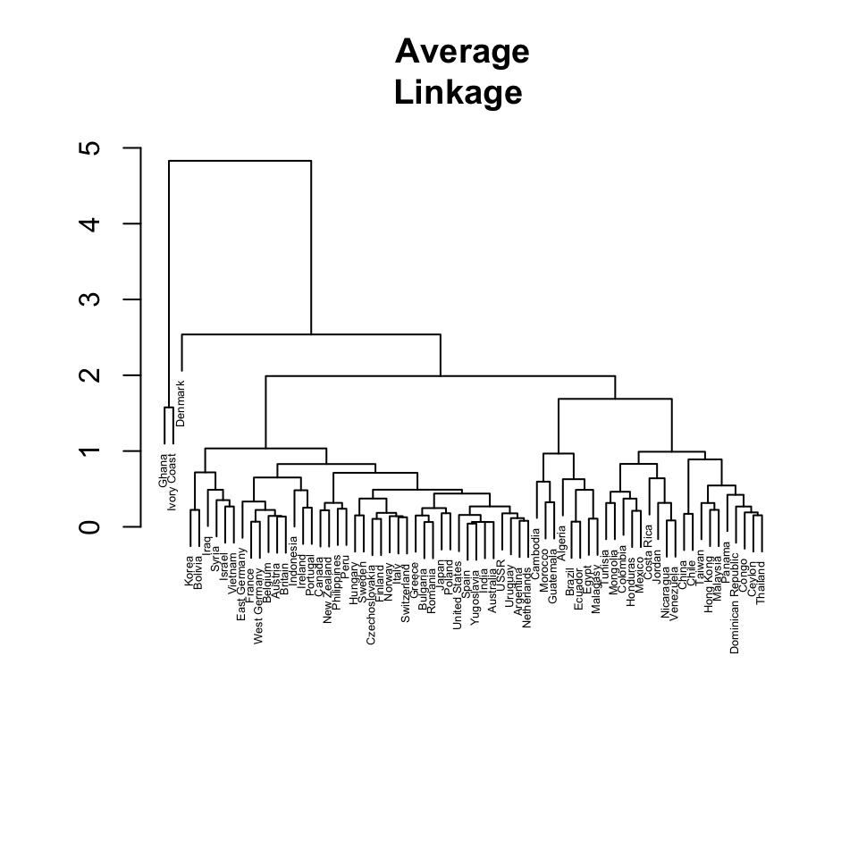

```r
plot(hclust(h.data.dist, method = 'average'), labels=data.labs , main="Average
Linkage ", xlab="", sub="",ylab="", cex = .4)
```

Centroid linkage similarly does exactly as described. The centroids of each cluster are found and then the smallest distance between all centroids determines the next merge of clusters. In our previous example, if point 1 is at (1,3) and point 2 is at (3,1), the centroid would be at (2,2). Point 3 would be its own centroid as it is not clustered with any other point. If the centroid of 4 and 5 was at (5,5) and point 3 was at (3,3), point 3 would merge with the cluster containing 1 and 2 and the new centroid would move up and to the right.

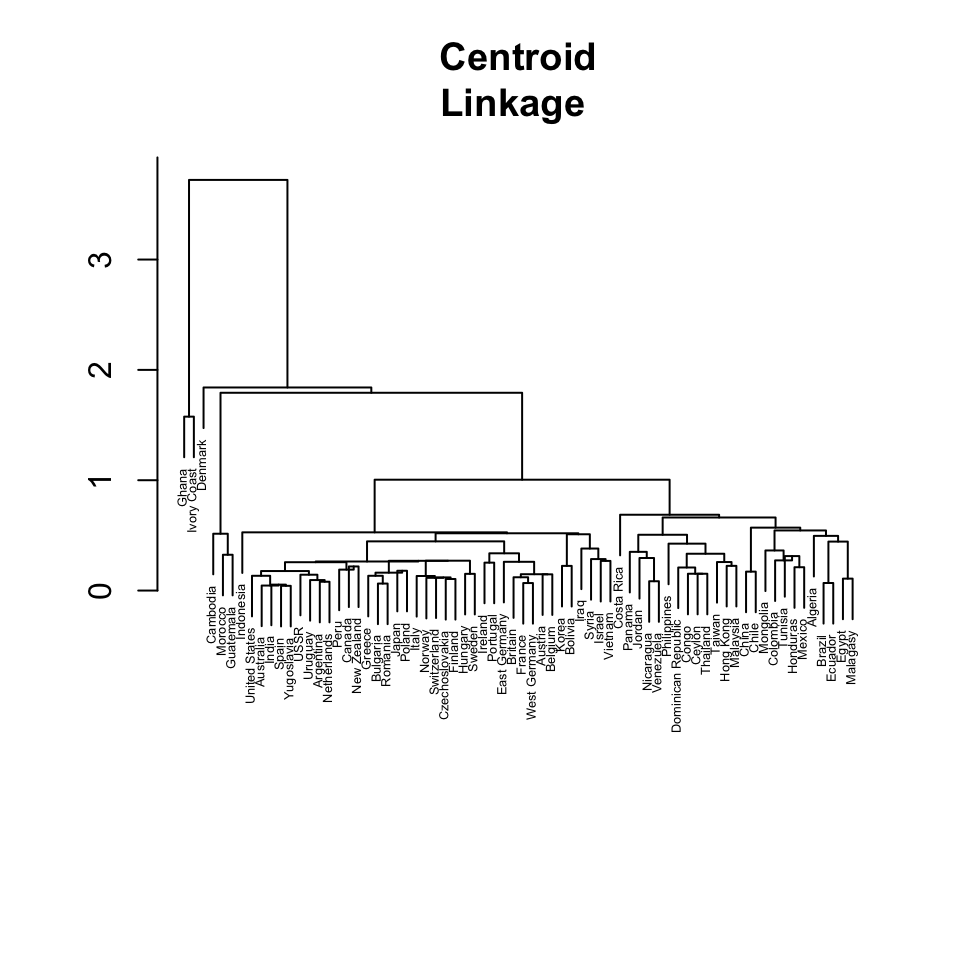

```r
plot(hclust(h.data.dist, method = 'centroid'), labels=data.labs , main="Centroid
Linkage ", xlab="", sub="",ylab="", cex = .4)
```

### Clustering Visualization

Dendrograms are a visual representation of the linkage processes. As seen above, the reason why Average and Complete Linkage are more commonly used is that it usually provides for more evenly grouped clusters at all thresholds. Below is the dendrogram of the data using complete linkage. When viewing the dendrogram below it is possible to see where these closest pairs end up. Where there is a lower split, the two observations are closer to each other and joined earlier in the linkage process. This does not mean that any adjacent observation is close to it’s adjacent observations. If a single observation connects to a group of observations, this means that the observation’s adjacency is to all of the observations in that adjacent branch in accordance to whichever linkage process took place. In higher splits, there is a higher distance between groups of observations. By setting a threshold of 2.5 in this example we produce 5 clusters. The names of the countries identified in these clusters can be viewed in the table (the head of the data is shown below). We can see how hierarchical clustering grouped the outliers in their own individual groups and then nicely separated the remaining countries into 3 understandable groups of high death rate/high birth rate, high birth rate/low death rate, and low birth rate/low death rate.

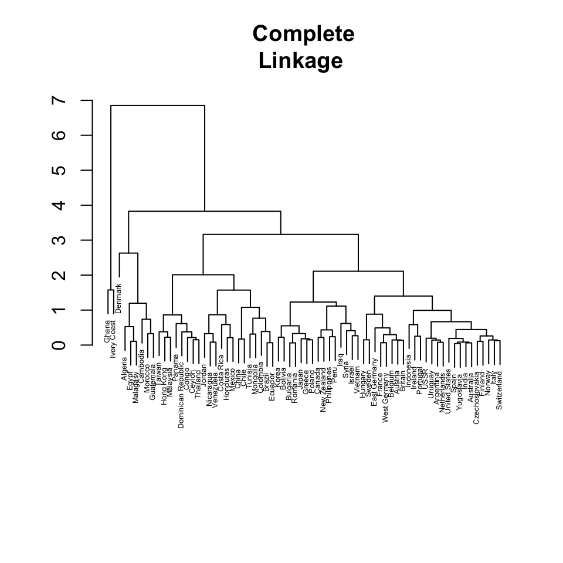

```r
plot(hclust(h.data.dist), labels=data.labs , main="Complete
Linkage ", xlab="", sub="",ylab="", cex = .4)
```

```r
hc.out=hclust(dist(sd.h.data))
hc.clusters =cutree (hc.out ,h = 2.5)
knitr::kable(head(tibble(country=data.labs,cluster=hc.clusters)),format="markdown")
```

| country | cluster |
| --- | --- |
| Algeria | 1 |
| Congo | 2 |
| Egypt | 1 |
| Ghana | 3 |
| Ivory Coast | 3 |
| Malagasy | 1 |

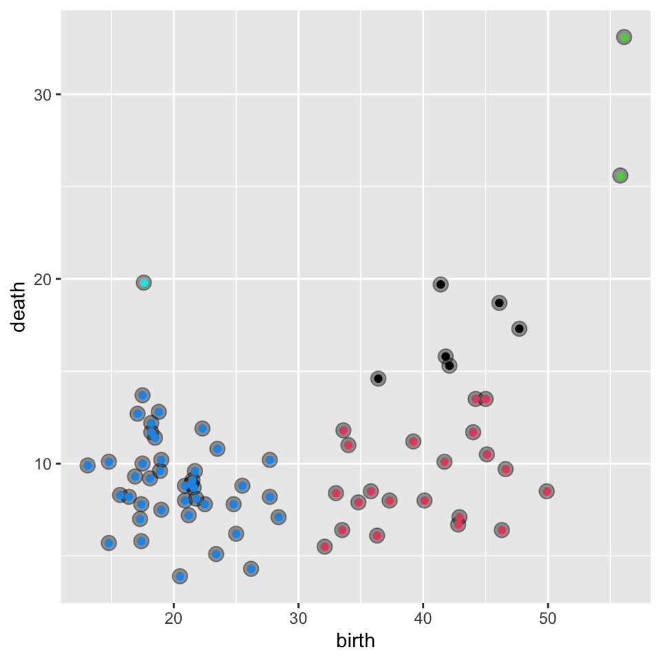

```r
ggplot(birth_death_rates, aes(birth, death)) +
  geom_point(alpha = 0.4, size = 3.5) + geom_point(col = hc.clusters)
```

## PCA and K-Means

Using the k-means clustering methods explored earlier, we can use a similar method to obtain clusters using the first two principal components obtained in the PCA section. First we need to find the optimum number of clusters. One way we approximated this earlier was by looking at the elbow of the SSE vs. K for the clusters plot:

```r
state_cluster = subset(state_tibble, select = -c(state) )
#-- Run kmeans for multiple K
graphData <- tibble()
Kmax = 8                              # maximum K
SSE = numeric(Kmax)                       # initiate SSE vector
for(k in 1:Kmax){
  km = kmeans(state_cluster, centers=k, nstart=25)   # use 25 starts
  SSE[k] = km$tot.withinss                # get SSE
  temp <- state_tibble
  temp$num_cluster <- k
  temp$cluster <- factor(km$cluster)
  graphData <- rbind(graphData,temp)
}
```

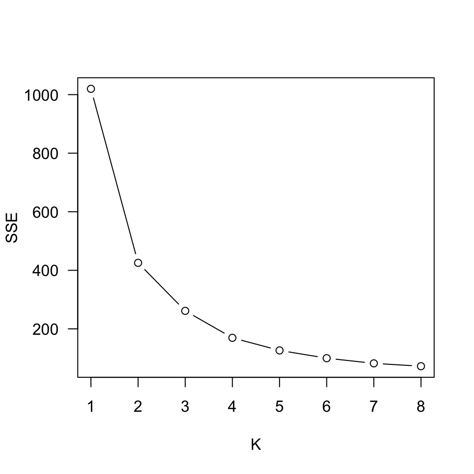

```r
plot(1:Kmax, SSE, type='b', las=1, xlab="K")
```

From the plot it seems as if the 3 is the elbow of the plot. Therefore we can initiate a k-means with 3 centers, meaning 3 clusters. Similar to earlier, the code goes like this:

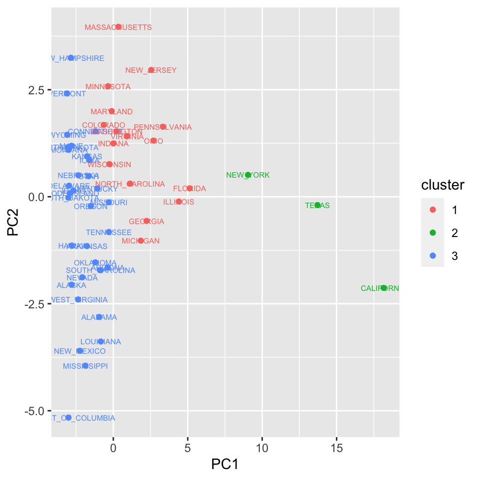

```r
state_km = kmeans(state_cluster, centers=3, nstart=25)
state_tibble$cluster <- factor(state_km$cluster)
ggplot(data=state_tibble, aes(x=PC1,y=PC2, color=cluster)) + geom_point()+ geom_text(label=state_tibble$state,size=2)
```

### PCA and Hierarchical Clustering

Much like how we were able to find clusters using the k-means approach, we may also obtain a dendrogram and clusters using hierarchical clustering. Once more, the only difference is now we use the principal components as the features. The code for executing all of the three types of clustering mentioned earlier are executed below:

##### Single Linkage

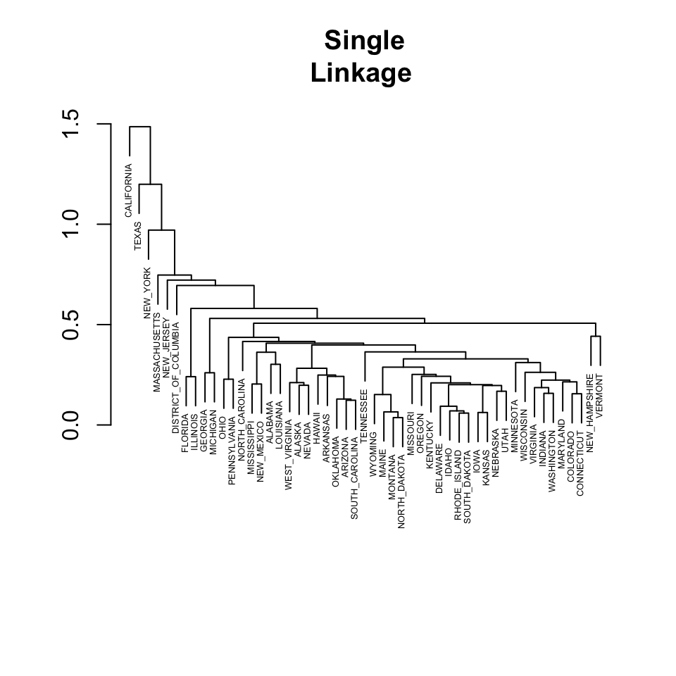

```r
state_tibble=tibble(PC1=educationPCA$x[,"PC1"],PC2=educationPCA$x[,"PC2"])
sd.state_tibble=scale(state_tibble)
state.dist=dist(sd.state_tibble)
plot(hclust(state.dist, method = 'single'), labels =states_education$STATE, main="Single
Linkage ", xlab="", sub="",ylab="", cex =.4)
```

##### Complete Linkage

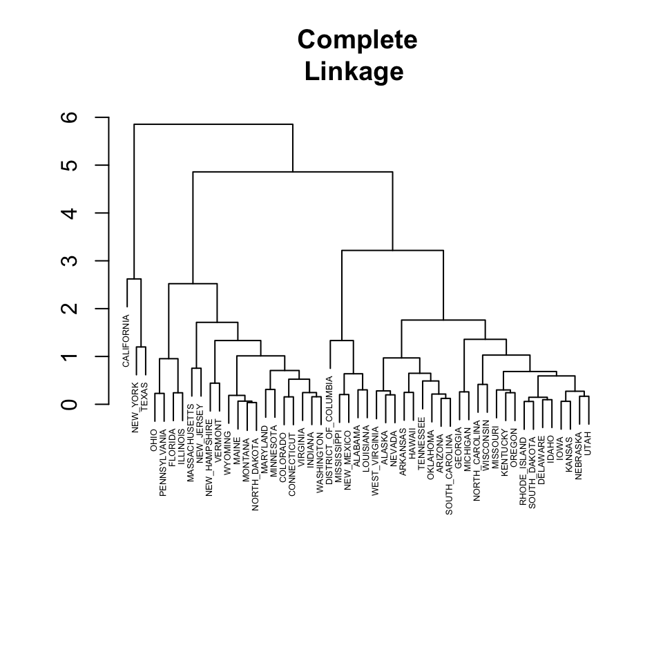

```r
plot(hclust(state.dist), labels=states_education$STATE , main="Complete
Linkage ", xlab="", sub="",ylab="", cex = .4)
```

##### Average Linkage

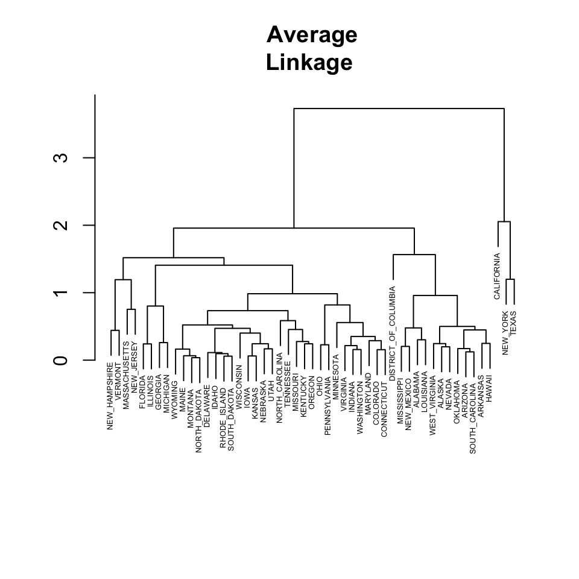

```r
plot(hclust(state.dist, method="average"), labels=states_education$STATE , main="Average
Linkage ", xlab="", sub="",ylab="", cex = .4)
```

And there you have it! As one can see PCA is a very useful tool that can be used in conjunction with other unsupervised learning methods such as clustering. Although we did not provide an example for using PCA with GMM, one can see that the applying PCA is as simple as changing the features that are imputed into the code. All you need to do is use your most significant principal components as the features in your model instead of the original features. From here you proceed as normal with regards to the steps laid out and you should obtain your results.

Hopefully you found this tutorial useful in your learning of unsupervised methods. If you are confused about any of the topics mentioned, we recommend you take a look at some of the sources used to create this material, which will surely help you answer any questions.

## References

[1] “Clustering Distance Measures.” Datanovia, 20 Oct. 2018, www.datanovia.com/en/lessons/clustering-distance-measures/.

[2] Hamerly, Greg. “(PDF) Alternatives to the k-Means Algorithm That Find Better Clusterings.” ResearchGate, www.researchgate.net/publication/221614137_Alternatives_to_the_k-means_algorithm_that_find_better_clusterings.

[3] Jaiswal, Sejal. “K-Means Clustering in R Tutorial.” DataCamp Community, 14 Mar. 2018, www.datacamp.com/community/tutorials/k-means-clustering-r.

[4] “k-Means Advantages and Disadvantages | Clustering in Machine Learning.” Google, Google, developers.google.com/machine-learning/clustering/algorithm/advantages-disadvantages.

[5] Porter, Michael. Clustering Notes, 2020, mdporter.github.io/SYS6018/lectures/06-clustering.pdf.

[6] Kodali, T. (2017, April 28). Hierarchical Clustering in R. Retrieved December 6, 2020, from https://datascienceplus.com/hierarchical-clustering-in-r/

[7] James, G., Witten, D., Hastie, T., & Tibshirani, R. (2017). An introduction to statistical learning with applications in R. New York: Springer.

[8] Kropko, Jonathan. “Surfing the Data Pipeline with Python.” Exploratory Data Analysis - Surfing the Data Pipeline with Python, 2020, jkropko.github.io/surfing-the-data-pipeline/ch10.html.

[9] “Prcomp.” RDocumentation, www.rdocumentation.org/packages/stats/versions/3.6.2/topics/prcomp.

[10] “Principal Component Analysis (PCA) Clearly Explained (2015).” Youtube, StatQuest, 13 Aug. 2015, www.youtube.com/watch?v=_UVHneBUBW0.

[11] “StatQuest: Principal Component Analysis (PCA), Step-by-Step.” Youtube, StatQuest, 2 Apr. 2018, www.youtube.com/watch?v=FgakZw6K1QQ.

[12] Woo, Jeffery. “Principal Components Analysis Video Lecture”. STAT 6021 Collab Page. Module 12: Shrinkage Methods. 2 Dec. 2020.